# Urban biodiversity: a study on Parisian trees

May, 24th 2019

## Motivation

## Methodological exercise

Recent developments in biodiversity measurement (Marcon et al. 2014).

Possible interfertilisation with measures of specialisation and spatial concentration in economics (Marcon 2019).

Applied to Paris trees data: explore the biodiversity of trees.

Urban trees provide many services (Taylor and Hochuli 2015). More diversity: more amenities and more resistance.

## Aims

Show similar approaches in different disciplines.

Discuss economic issues:

- MAUP,
- absolute vs. relative concentration.

Illustrate with trees for SEW 2019.

## Data

Paris open data: https://opendata.paris.fr

Dataset: 200,000 trees in Paris located in 20 arrondissements.

- Streets, Beltway,
- Public gardens, Cemeteries,
- Schools, Nurseries, Sports facilities.

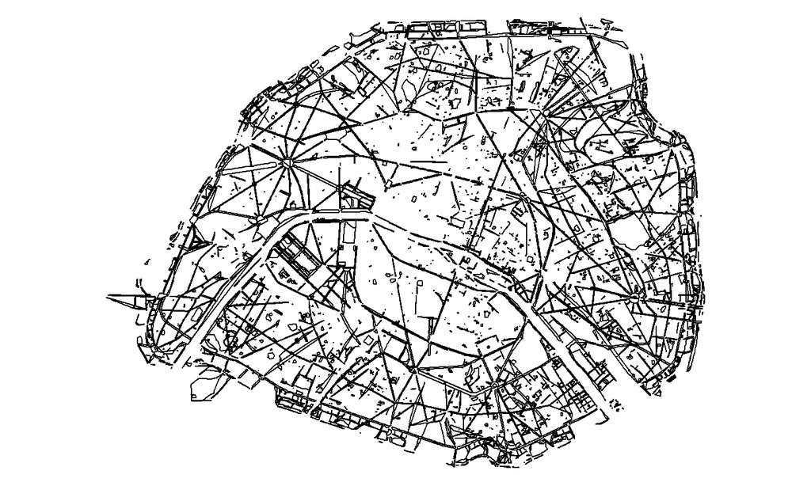

Reproducible research: [on GitHub](https://github.com/EricMarcon/ParisTrees).

Made with R, knitr, sp, [entropart](https://ericmarcon.github.io/entropart/).

## Most abundant species

Hybrid plane tree, horse chestnut, scholar tree, lime tree, Norway maple, sycamore maple…

| Species | Number of Trees |
| --- | --- |
| Platanus x hispanica | 33297 |
| Aesculus hippocastanum | 15507 |
| Sophora japonica | 10714 |
| Tilia tomentosa | 6987 |
| Acer platanoides | 4423 |
| Acer pseudoplatanus | 4417 |

## Species distribution

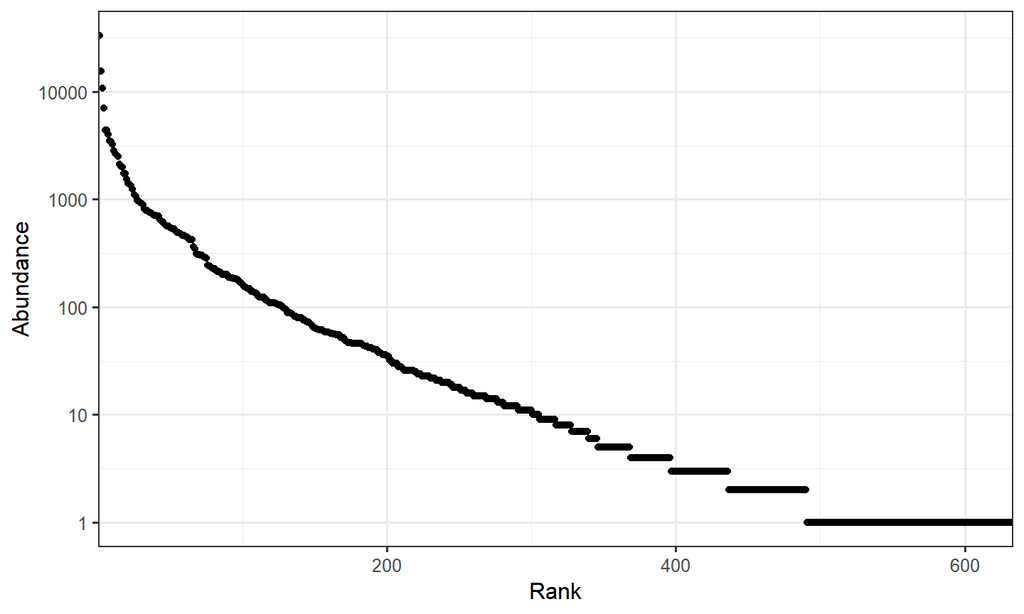

## Measures of diversity

## Aims

We want to measure the diversity of trees in Paris arrondissements.

Equivalent in economics: measure the specialisation of Paris arrondissements.

Information theory is appropriate.

## Measuring Uncertainty

An experiment with several outcomes \(\{r_1, \dots, r_s, \dots, r_S \}\):

- The probability to obtain \(r_s\) is \(p_s\).

Information function: \(I(p_s)>0, p_s\in [0, 1[\), decreasing to \(I(1)=0\).

- Definition: rarity is \(1/p_s\).
- The logarithm of rarity is Shannon’s information function.

The expectation of the information carried by an individual is Shannon’s entropy: \[\sum_s{p_s \ln {\frac{1}{p_s}}}\]

## Theil’s index

Theil’s index of specialisation is \[\ln{S} - \sum_s{p_s \ln {\frac{1}{p_s}}}\]

Specialisation is opposed to diversity.

## Generalized Entropy

Parametric entropy (Tsallis 1988; Brülhart and Traeger 2005)

Deformed logarithm: \(\ln_q x = \frac{x^{1-q} -1}{1-q}\)

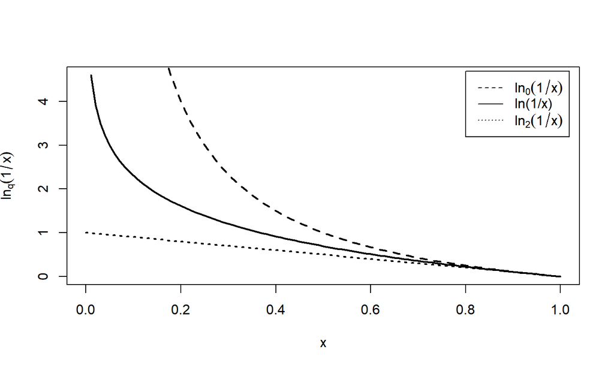

## Formalism

Tsallis entropy \(\sum_s{p_s \ln_q {\frac{1}{p_s}}}\) is the average (deformed, of order \(q\)) logarithm of rarity.

The order \(q\) stresses small or high probabilities.

- Entropy of order 0: the number of possible outcomes (-1), called *richness*.
- Entropy of order 1: Shannon (\(\ln{S}-\) Theil)
- Entropy of order 2: Simpson (1-Herfindahl).

## Hill Numbers

The number of equiprobable outcomes that have the same entropy as the observed system (Hill 1973). Exponential of entropy (Marcon et al. 2014).

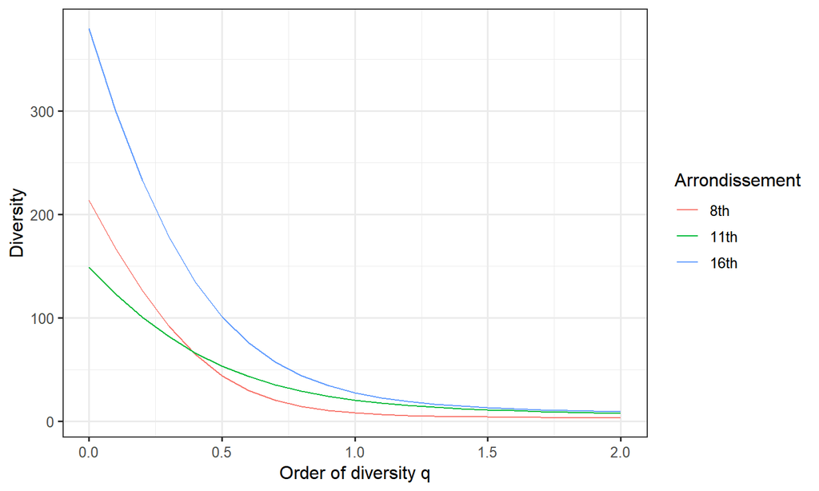

## Diversity of Parisian green spaces

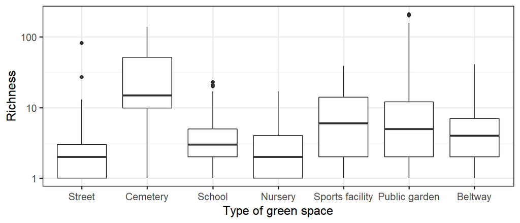

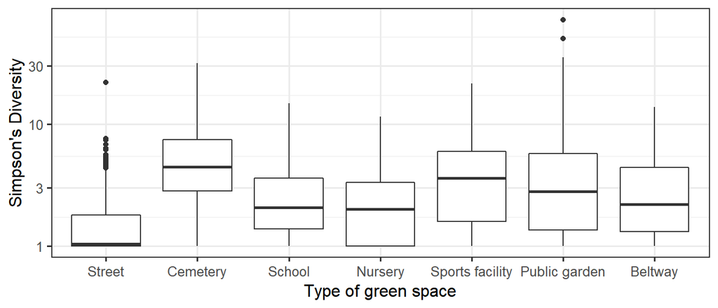

## Richness of arrondissements

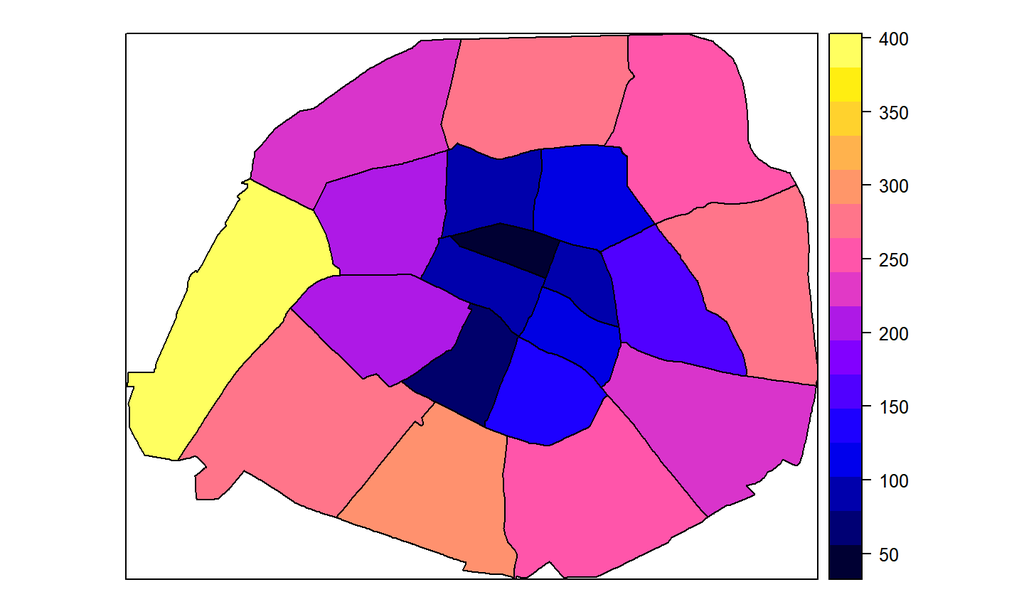

## Shannon’s Diversity

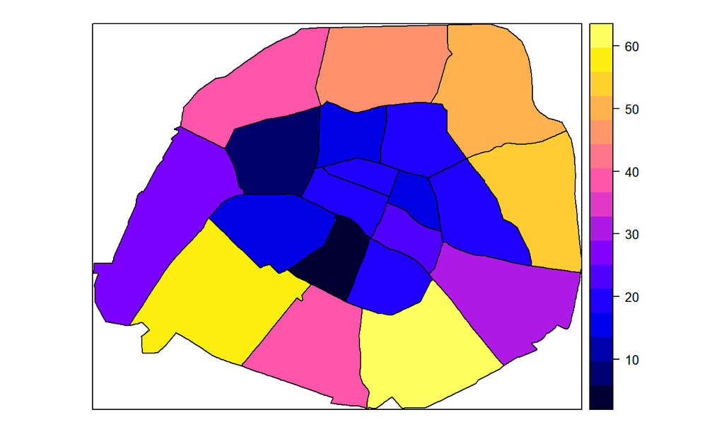

## Simpson’s Diversity of arrondissements

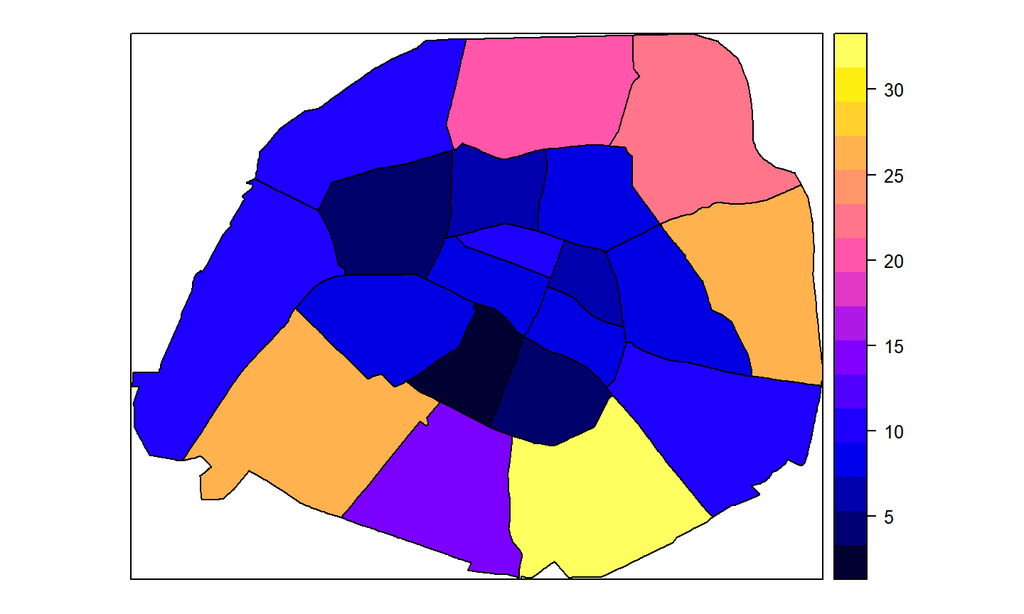

## Measures of spatial concentration

## Similar approach

We want to measure the spatial ubiquity of species.

Consider a species.

The event \(r_i\) *A tree of arrondissement \(i\) belongs to the species* has probability \(p_i\).

Ubiquity is the effective number of arrondissements the species is present in.

Spatial concentration is opposed to ubiquity.

## Ubiquity of abundant species

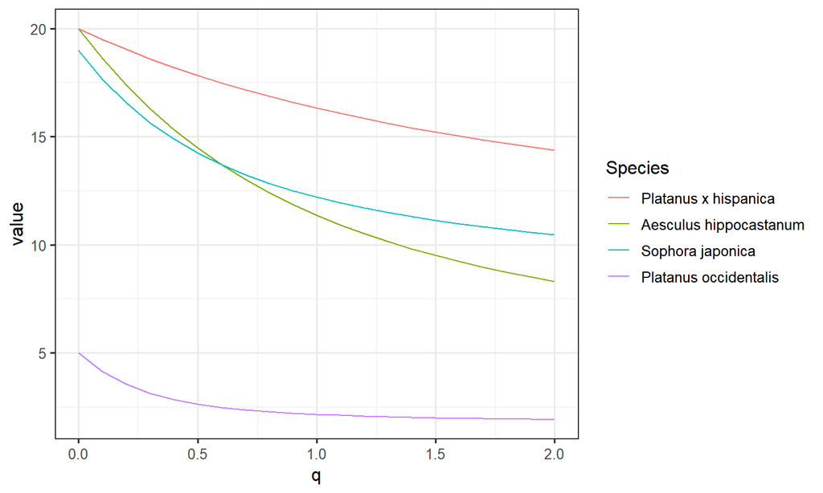

## Relative vs Absolute

## Motivation

Clarify the links between relative and absolute diversity/ubiquity.

Deal with the MAUP.

## Two types of diversity

In search for biodiversity in public gardens:

- Choose the arrondissement where public gardens are more diverse on average.
- Choose the one where they are more different from each other.

Absolute or relative diversity \(\leftrightarrow\) \(\alpha\) or \(\beta\) diversity.

## The richness of parks and gardens

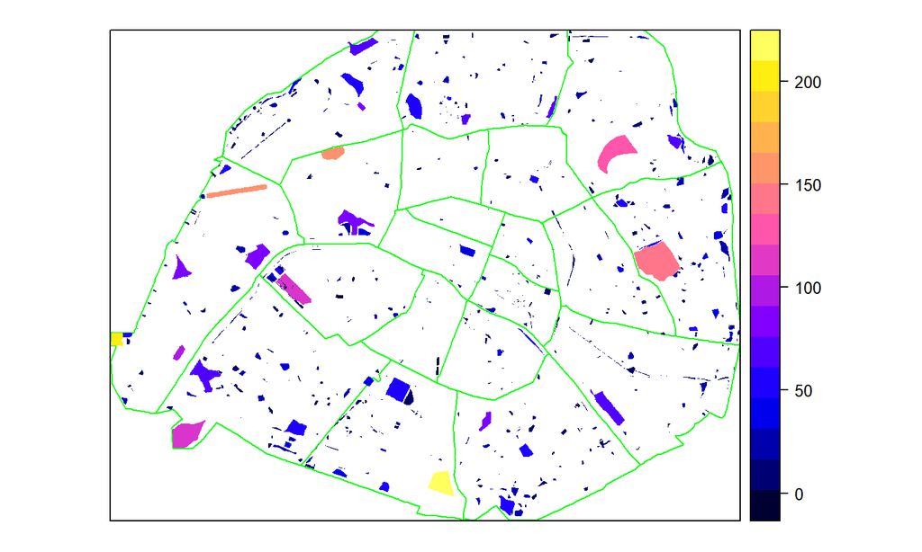

## Decomposition

Rules:

- Entropy(arrondissement) = entropy(within parks) + entropy(between parks)
- Diversity(arrondissement) = Diversity(within parks) X Diversity(between parks)
- Dimensions of diversity: # Species = # Species/park X # Parks

and, similarly:

- Spatial concentration(all trees) = concentration(within species) X concentration(between species)

## Within diversity of public gardens

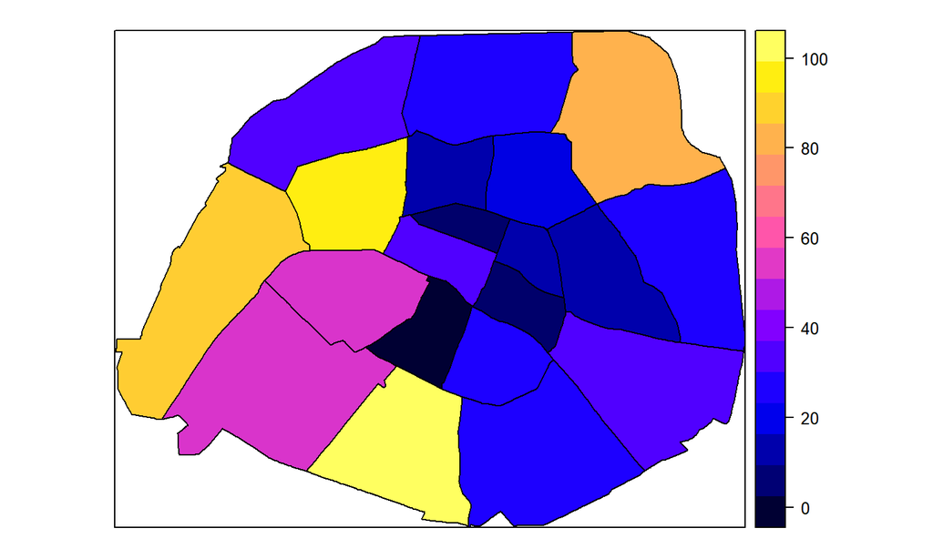

## Between diversity of public gardens

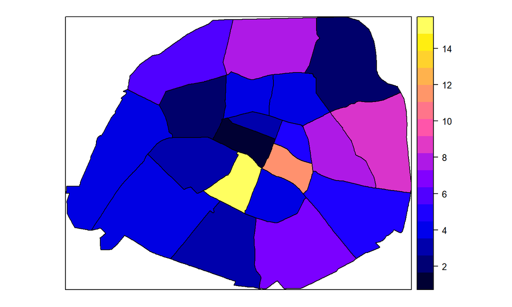

## Total diversity of public gardens

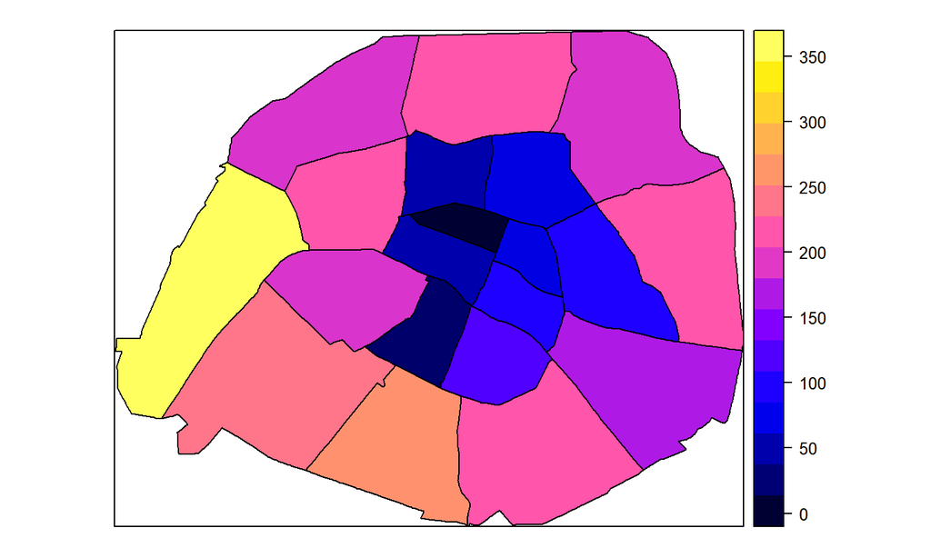

## MAUP

Diversity/Ubiquity increases when data are aggregated:

- Scale effect of the MAUP.
- Actually increases by *between diversity*: not a problem but a feature.

## Conclusion

## Urban biodiversity

The biodiversity of Paris trees is comparable to that of the most diverse tropical forests.

Many introduced species.

High variability:

- Streets are not diverse. Sanitary issues.
- Some parks imitate nature, some are collections.
- Cemeteries are more diverse than parks (at low \(q\)).

## Key messages

Diversity \(\leftrightarrow\) Specialisation.

Ubiquity \(\leftrightarrow\) Spatial concentration.

Hill numbers unify many metrics.

Key importance of the order of diversity/ubiquity:

- Theil\(\leftrightarrow q=1\);
- Ellison and Glaeser\(\leftrightarrow q=2\).

Partitioning solves the scale effect of the MAUP.

## References

Brülhart, Marius, and Rolf Traeger. 2005. “An Account of Geographic Concentration Patterns in Europe.” *Regional Science and Urban Economics* 35 (6): 597–624. https://doi.org/10.1016/j.regsciurbeco.2004.09.002.

Hill, M. O. 1973. “Diversity and Evenness: A Unifying Notation and Its Consequences.” *Ecology* 54 (2): 427–32. https://doi.org/10.2307/1934352.

Marcon, Eric. 2019. “Mesure de la biodiversité et de la structuration spatiale de l’activité économique par l’entropie.” *Revue économique* 70 (3): 305–26.

Marcon, Eric, Ivan Scotti, Bruno Hérault, Vivien Rossi, and Gabriel Lang. 2014. “Generalization of the Partitioning of Shannon Diversity.” *Plos One* 9 (3): e90289. https://doi.org/10.1371/journal.pone.0090289.

Taylor, Lucy, and Dieter F. Hochuli. 2015. “Creating better cities: how biodiversity and ecosystem functioning enhance urban residents’ wellbeing.” *Urban Ecosystems* 18 (3): 747–62. https://doi.org/10.1007/s11252-014-0427-3.

Tsallis, Constantino. 1988. “Possible generalization of Boltzmann-Gibbs statistics.” *Journal of Statistical Physics* 52 (1): 479–87. https://doi.org/10.1007/BF01016429.